# Testes de Hipótese x Intervalos de Confiança

Rayssa

4 de agosto de 2017

# Aplicando Teste de Hipótese

Iremos refazer a análise do checkpoint anterior utilizando *teste de hipótese*, para compararmos as respostas. A descrição das variáveis e a resposta encontrada através do intervalo de confiança no checkpoint anterior estão descritas logo abaixo.

## Dados no github

Neste relatório vamos analisar uma amostra de dados da atividade global do github disponível neste link https://raw.githubusercontent.com/nazareno/fpcc2/master/datasets/github-users-committing-filetypes.csv durante 2016 e 2017, para respondermos algumas perguntas sobre liguagens de programação utilizadas pelos os usuários que fazem uso do github.

## Descrição dos dados utilizados

Para esta análise iremos utilizar as seguintes variáveis: *file_extension* que corresponde a extensão do arquivo manipulado pelo usuário, *month_day* o dia do mês, *the_month* o mês, *the_year* o ano em que o arquivo foi criado/modificado e *users* a quantidade de pessoas que editou os arquivos.

```r
dadosGithub <- read.csv("../dados/github-users-committing-filetypes.csv")

dadosGithub$date <- paste(dadosGithub$month_day, dadosGithub$the_month, dadosGithub$the_year, sep = "-")
```

## Respondendo através do intervalo de confiança

**1) Segunda e sexta têm popularidade maior que terça, quarta e quinta para a linguagem Java?**

Vamos tentar descobrir se os desenvolvedores que utilizam a linguagem *Java* são mais produtivos no meio da semana (terça, quarta e quinta) do que nos dias extremos da semana (segunda e sexta). Para isso iremos filtrar os dados com commits de arquivos Java e separá-los em meio da semana e extremos da semana. E logo depois iremos utilizar a técnica bootstrap para termos confiança na resposta que iremos encontrar; utilizaremos esta técnica para coletar informações da amostra de forma que possamos determinar um intervalo de confiança do valor da diferença da popularidade de Java no meio da semana e nos dias extremos da semana.

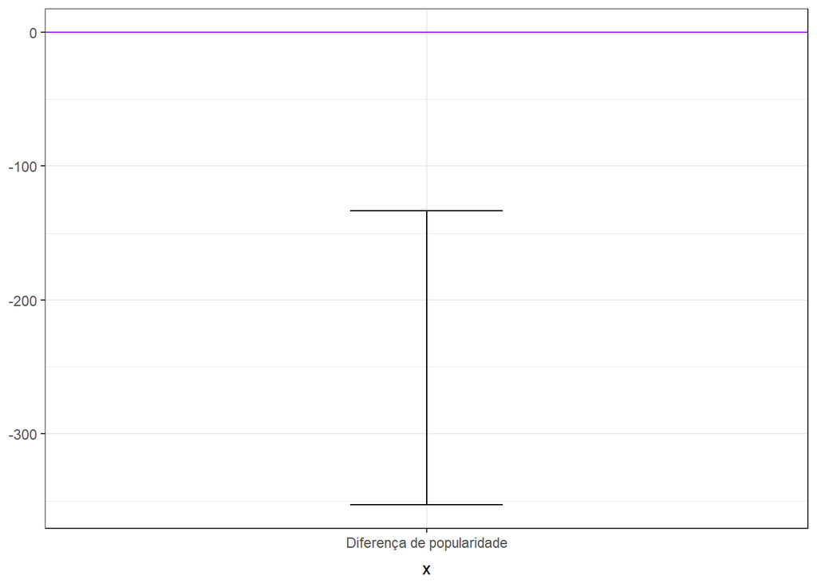

```r
java <- dadosGithub %>%
  filter(file_extension == 'java') %>%
  mutate(weekday = weekdays(as.Date(date,'%d-%m-%Y')))

extremos_semana <- java %>%
  filter(weekday == "segunda-feira" | weekday == "sexta-feira")

meio_da_semana <- java %>%
  filter(weekday == "terça-feira" | weekday == "quarta-feira" | weekday == "quinta-feira")

java_semana <- java %>%
  filter(weekday != "sábado" , weekday != "domingo" )


median <- bootstrap2(data = (extremos_semana)$users,
               data2 = (meio_da_semana)$users,
               median)

median_ci = CI.percentile(median, probs = c(.025, .975), na.rm=TRUE)

data.frame(median_ci) %>%
  ggplot(aes(x = "Diferença de popularidade", ymin = X2.5., ymax = X97.5.)) +
  geom_errorbar(width = .2) +
  geom_hline(yintercept = 0, colour = "purple")
```

De acordo com o gráfico mostrado acima podemos verificar que com 95% de confiança a diferença das medianas de popularidade entre os dias extremos da semana e o meio da semana para a linguagem *Java* está no intervalo entre -353, -133.5 . Assim percebemos que Java é uma liguagem que os usuários utilizam muito mais durante o meio da semana do que nas segundas e sextas. Desta forma podemos concluir que essa diferença é relevante e tem essa significância de que com 95% de confiança se encontra no intervalo mencionado anteriormente.

## Respondendo através do Teste de Hipótese

Primeiramente vamos guardar as diferenças das medianas observadas na nossa amostra para a atividade dos programadores Java durante os extremos da semana e o meio da semana.

```r
mediana_extremo_semana <- extremos_semana %>%
  summarise(mediana = median(users))

mediana_meio_da_semana <- meio_da_semana %>%
  summarise(mediana = median(users))

medianas <- data.frame(mediana2=c(mediana_extremo_semana$mediana ,mediana_meio_da_semana$mediana))
diff.mediana.observada = diff(medianas$mediana2)
```

A diferança encontrada para nossa amostra foi a seguinte *250*.

Agora vejamos o quão frequente seria encontrarmos uma diferença do tamanho que encontramos se não houvesse associação nenhuma entre qual é o dia da semana e qual é a quantidade de commits por dia para a linguagem Java. A situação onde não existe associação é a *hipótese nula*. Se a diferença que observamos em nossa amostra acontece facilmente na hipótese nula, isso significa que não temos evidência forte de associação: o que observamos acontece também quando não há associação. No caso onde a diferença que observamos é improvável na hipótese nula, então observamos algo que é indicativo de associação.

```r
set.seed(1)
glimpse(java_semana)
```

```
## Observations: 354
## Variables: 7
## $ file_extension <fctr> java, java, java, java, java, java, java, java...
## $ month_day      <int> 26, 19, 20, 24, 12, 13, 27, 23, 6, 18, 15, 27, ...
## $ the_month      <int> 4, 4, 4, 2, 4, 4, 4, 2, 4, 5, 3, 1, 3, 3, 5, 5,...
## $ the_year       <int> 2016, 2016, 2016, 2016, 2016, 2016, 2016, 2016,...
## $ users          <int> 4458, 4455, 4409, 4373, 4369, 4322, 4280, 4278,...
## $ date           <chr> "26-4-2016", "19-4-2016", "20-4-2016", "24-2-20...
## $ weekday        <chr> "terça-feira", "terça-feira", "quarta-feira", "...
```

```r
diffs = replicate(10000, {
  medianas = java_semana %>%
    mutate(id_embaralhado = sample(weekday, n())) %>%
    group_by(id_embaralhado) %>%
    summarise(mediana = median(users))
  extremos_semana_java = medianas %>%
    filter(id_embaralhado == "segunda-feira" | id_embaralhado == "sexta-feira")
  extremos_semana_java_mediana <- extremos_semana_java %>%
    summarise(med=median(mediana))
  meio_da_semana_java = medianas %>%
    filter(id_embaralhado == "terça-feira" | id_embaralhado == "quarta-feira" | id_embaralhado == "quinta-feira")
   meio_da_semana_java_mediana <- meio_da_semana_java %>%
    summarise(med=median(mediana))
  return(extremos_semana_java_mediana - meio_da_semana_java_mediana)
})
glimpse(unlist(diffs))
```

```
##  Named num [1:10000] 23 -43 138 39 51 ...
##  - attr(*, "names")= chr [1:10000] "med" "med" "med" "med" ...
```

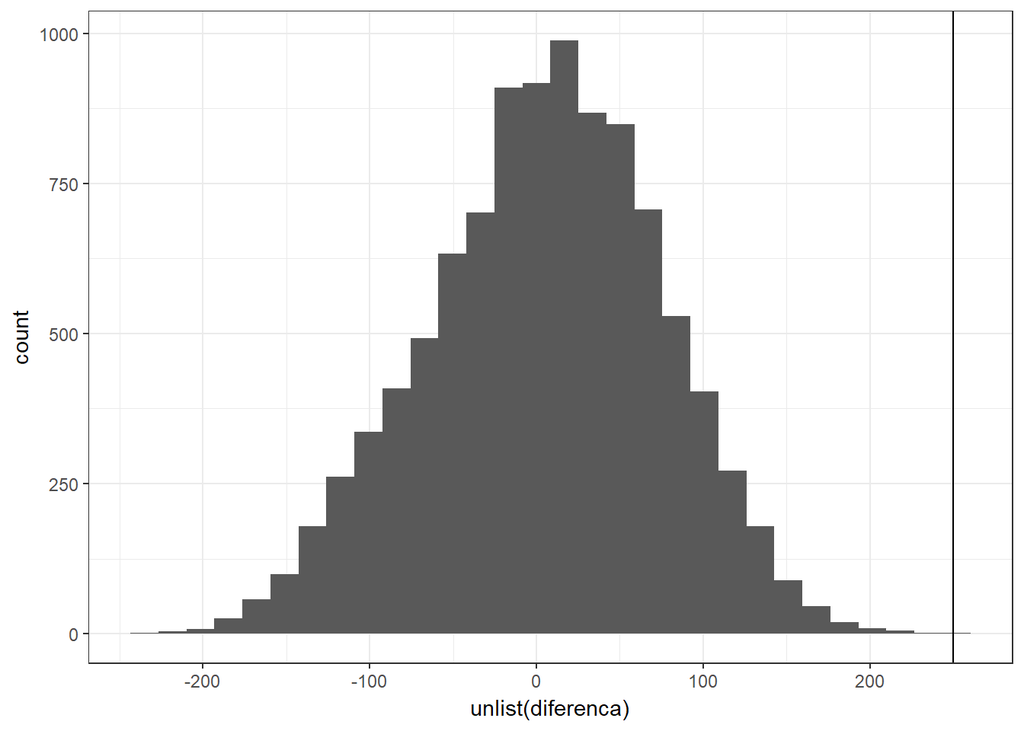

```r
tibble(diferenca = diffs) %>%
  ggplot(aes(x=unlist(diferenca))) +
  geom_histogram(bins= 30) +
  geom_vline(xintercept = diff.mediana.observada)
```

```r
# p-valor!
p.valor = sum(abs(unlist(diffs)) >= abs(diff.mediana.observada)) / length(unlist(diffs))
p.valor
```

```
## [1] 1e-04
```

## O que significa o p-valor?

O p-valor é definido como a probabilidade de se observar um valor da estatística de teste maior ou igual ao encontrado. Geralmente, o valor de corte para rejeitar a hipótese nula é de 0,05, o que significa que, quando não há nenhuma diferença, um valor tão extremo para a estatística de teste é esperado em menos de 5% das vezes. Desta forma podemos dizer que o p-valor encontrado acima corresponde a probabilidade que mede quantos dos valores encontrados são maiores ou iguais ao valor observado na nossa amostra, quando a hipótese nula é verdadeira.

## Comparação do resultado com IC x Teste de Hipótese

De acordo com as duas respostas, utilizando intervalo de confiança (IC) e teste de hipótese, podemos perceber que ambas chegam no mesmo resultado. A única diferença entre elas é que ao utilizarmos IC conseguimos saber da relevância que os resultados possuem e podemos controlar a significância dos mesmos.